# Can science TUNE photosynthesis?

## Why Bioengineer Photosynthesis?

- **Growing global population and climate change threaten food security**
  - there IS limited land to grow more crops
- **C3 crops (e.g., rice, wheat, soybean) are limited by photorespiration, inefficient carbon fixation, and inefficient water use**
  - all made worse under climate change factors (heat and drought)
- **Improving photosynthesis is a key strategy for increasing crop yield and resilience**
  - Bioengineering photosynthesis is a frontier for sustainable agriculture

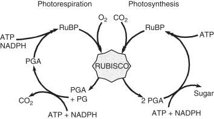

## The Problem with C3 Photosynthesis: Review

- **Rubisco, the key enzyme, can bind O<sub>2</sub> instead of CO<sub>2</sub>, especially under heat and drought**
  - leads to *photorespiration* – a wasteful process that reduces yield
  - forces stomata to be open more = more water loss
  - reduces carbon fixation
- **C3 plants lack mechanisms to concentrate CO<sub>2</sub> around Rubisco**
- **Eliminating photorespiration as a process is unrealistic**
  - but can we *tweak* Rubisco or other processes?

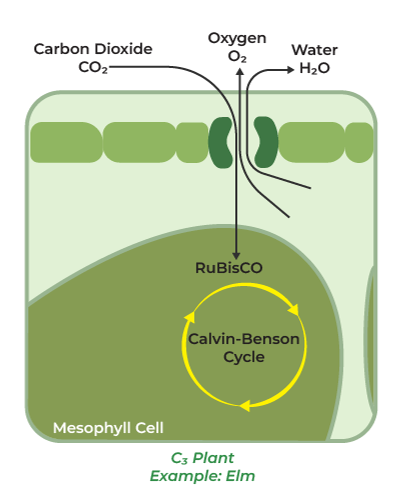

## Why Bioengineer Photosynthesis?

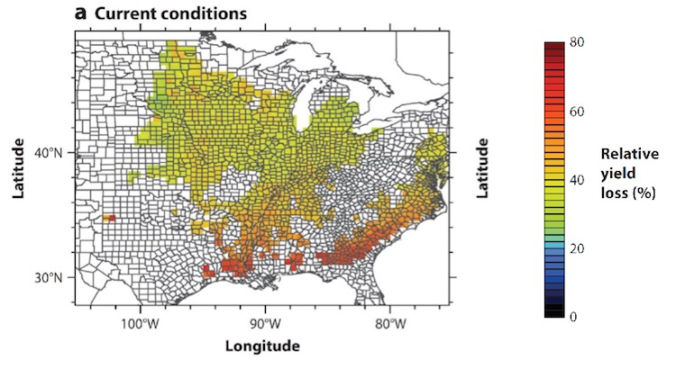

## Approaches to Photosynthesis Engineering are Complex

**1-Photorespiration produces a toxic byproduct called *glycolate*, which wastes energy to detoxify**  
*Engineeer new metabolic pathways (from bacteria or algae) into the plant’s chloroplasts to quickly recycle glycolate into useful products*

**2-Rubisco has a higher affinity for O<sub>2</sub> than CO<sub>2</sub> and is also slow**  
*Modify Rubisco’s structure or assemble Rubisco from cyanobacteria or algae that have better kinetic properties*

**3-The dilemma of stomatal behavior limits photosynthesis**  
*Introduce PEPC and nocturnal CO<sub>2</sub> fixation pathways (via CAM pathway)*

**4-The messy structure of C3 leaf anatomy is inefficient in supplying light and CO<sub>2</sub>**  
*Alter regulatory genes for mesophyll density, vein spacing, intercellular air space, or stomatal distribution*  
*Alter regulatory genes that control Kranz anatomy (C4) and express C4 enzymes in the right cell types*

## Is C4 Photosynthesis the Cure?

- **C4 plants (e.g., maize, sugarcane) spatially separate CO<sub>2</sub> fixation and the Calvin cycle**
- **CO<sub>2</sub> is first fixed in mesophyll cells (via PEPC), then shuttled to bundle sheath cells where the Calvin cycle occurs**
  - reduces photorespiration and increases efficiency (CO<sub>2</sub> released, O2 kept out)
  - especially in hot, dry environments.
- **C4 plants can have up to 50% higher photosynthetic rates under high light, heat, and drought compared to C3 plants**
  - use about half as much water to fix the same amount of carbon

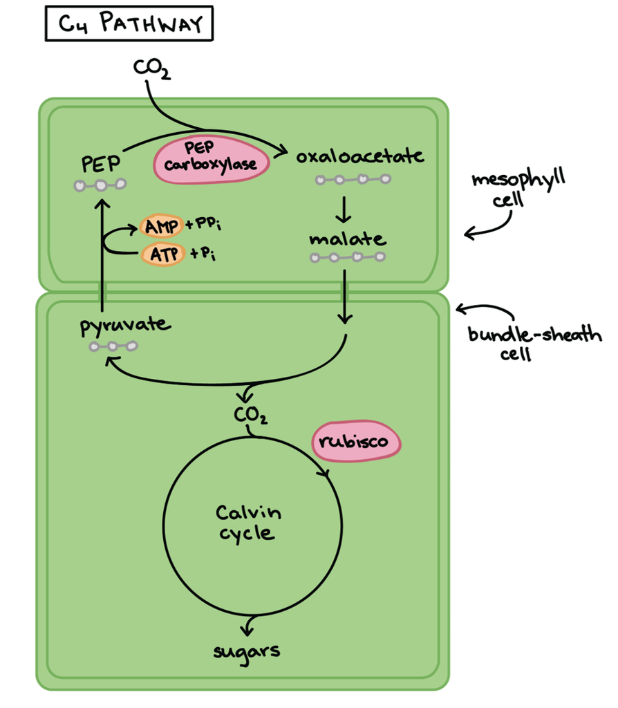

## The C4 Rice Project

- **C4 rice is a flagship project, with potential for higher yields and reduced water use**
  - https://c4rice.com/
- **Goal: Introduce C4 traits into rice (a C3 crop) to increase photosynthetic efficiency**
  - Focus areas: installing Kranz anatomy, expressing C4 enzymes
  - Challenges: complex genetic regulation and developmental changes
- **Understanding photosynthetic anatomy and genetics is key to the next breakthroughs**

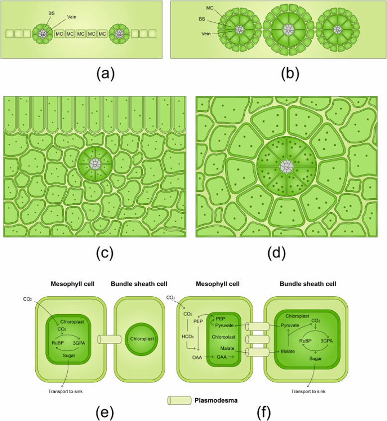

## It Is Time For A…

**Understanding photosynthetic anatomy and genetics is key to the next breakthroughs.**

[figure not shown]